# Data Visualization Portfolio

Author

D’Angelo Francis

```r
library(tidyverse)
library(fontawesome) # install.packages("fontawesome") - for waffle graphs
library(styler) # install.packages("styler") - check for Tidy style guide adherence
library(lintr) # install.packages("lintr") - check for Tidy style guide adherence
library(tidyverse)
library(readxl)
library(haven)
library(tidyverse)
library(patchwork) # easy combine plots
library(tigris) # direct download of shape files from US Cenus
library(sf) # manipulate shapefiles
library(tidycensus) # shapefiles from Census
library(rgeoboundaries) # international boundaries
library(ggrepel)  # install.packages("ggrepel")
library(janitor)  # install.packages("janitor")
library(ggthemes) # install.packages("ggthemes")
library(crsuggest) # install.packages("crsuggest")
```

## Visualization 1 - Broadband Infrastructure and Foreign Direct Investment in the Carribean

### Purpose

The purpose of this visualization is to demonstrate the benefit of net foreign direct investment (FDI) in expanding access to broadband internet in the Caribbean. Specifically, I am exploring the relationship between FDI net inflow and broadband access[^1] from 2013-2023 with respect to the World Bank’s definition of Caribbean Small States and Hispaniola (Haiti and the Dominican Republic.[^2]

I have omitted larger Caribbean states such as Jamaica and Cuba as well as non-sovereign overseas territories and provinces due to extreme outliers. I have also omitted some points due to overlap, as some years had extremely similar yearly FDI inflow values. I do not expect these adjustments to misrepresent the data. Importantly, I want the end user to observe the stark difference between Haiti and the Dominican Republic despite being neighbors on the same island.

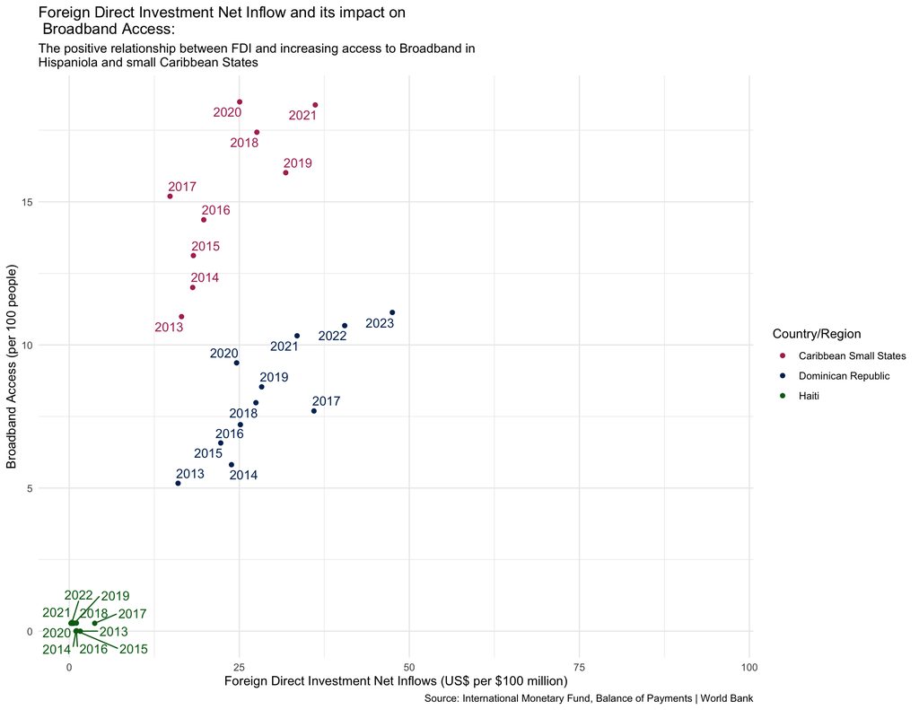

```r
## Visualization 1:

# import and clean data, continue to 'tidy' data to 4 variable categories

broadband <-
  read_excel("data/Fixed broadband subscriptions (per 100 people).xlsx")|>
  pivot_longer(
    cols = 3:28, # what I'm pivoting
    names_to = "year", # the new column for what I'm pivoting
    values_to = "access" # where column values go
  ) |>
  rename(
    code = `Country Code`, # for easy variable calling later on
    name = `Country Name`
  ) |>
  remove_missing()

# bring in FDI data

fdi_inflow <-
  read_excel("data/Foreign direct investment^J net inflows (BoP^J current US$).xlsx") |>
  pivot_longer(
    cols = 3:56,
    names_to = "year",
    values_to = "fdi"
  ) |>
  rename(
    code = `Country Code`,
    name = `Country Name`
  ) |>
  remove_missing() |>
  mutate(fdi = fdi/100000000)

# join fdi and broadband data for easy use

broadband_fdi_inflow <-
  right_join(broadband, y = fdi_inflow, by = join_by(name, code, year))

# filter year to 1998 for broadband

broadband_fdi_inflow98 <-
  broadband_fdi_inflow |>
  filter(year %in% c("1998":"2023"))

# choose countries of interest - I want to focus on Caribbean

broadfdi_Carib98 <-
  broadband_fdi_inflow98 |>
  filter(code %in% c("ABW","ATG","BHS","BMU","BRB", "CSS", "CUB", "CUW","CYM", "DMA", "DOM", "GRD", "HTI", "JAM", "KNA", "LCN", "LCA", "NAC", "PRI", "TCA","VCT","VGB","VIR"))

# Narrowing time frame to 2013 - 2023

broadfdi_Carib2013 <-
  broadfdi_Carib98|>
  filter(year %in% c("2013":"2023"))

# select country of interest ; color thru vars must be passed through aes *duh*

# to-do Wednesday and Thursday: refine legend and annotations.

haiti_dom_plot <- # this is the 'base' plot
  broadfdi_Carib2013 |>
  filter(code %in% c("CSS","DOM","HTI")) |>
  ggplot(aes(x = fdi, y = access, label = year, color = code)) +
  geom_point(position = "jitter") +
  scale_color_manual(name = "Country/Region",
                     values = c(CSS = "maroon", DOM = "#002D62", HTI = "#016a16"),
                                labels = c(CSS = "Caribbean Small States",
                                           DOM = "Dominican Republic",
                                           HTI = "Haiti")) + # custom color
  geom_text_repel(show.legend = FALSE, max.overlaps = 20) +
  theme_minimal() +
  labs(
    title = "Foreign Direct Investment Net Inflow and its impact on \n Broadband Access:",
    subtitle = str_wrap("The positive relationship between FDI and increasing access to Broadband in Hispaniola and small Caribbean States"),
    caption = strwrap("Source: International Monetary Fund, Balance of Payments | World Bank Open Data")
  ) +
  xlab("Foreign Direct Investment Net Inflows (US$ per $100 million)") +
  ylab("Broadband Access (per 100 people)")

haiti_dom_plot
```

## Visualization 2 - Japan’s railroad infrastructure and its relationship with Gross Regional Domestic Product (GRDP)

### Purpose

The purpose behind this visualization cis to emphasis how railroad investment contributes to economic success. Japan has an extensive network of both private and government-owned railroads[^3] that efficiently ships foreign imports from the major ports of Japan and ferry commuters between the office and their home. Japan’s high-speed rail system—the *shinkansen*, is vaunted for its ability to travel between major cities while maintaining superb passenger comfort and boosting regional economic growth.[^4]

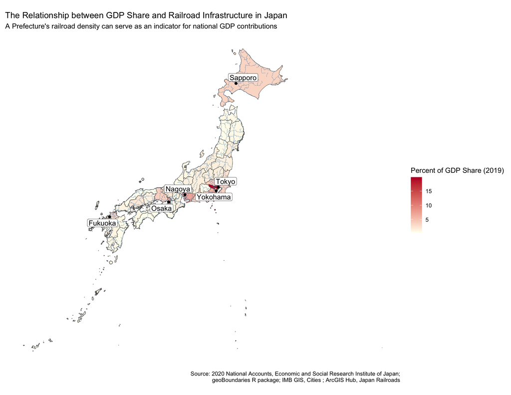

```r
# load japan geofile in

japan <-
  gb_adm1("japan") # get lvl1 adm map of Japan (~47 prefectures)

# load rail data in

japan_rail <-
  read_sf("data/Japan_railroads.geojson") |> # read in railroad map
  clean_names() |>
  rename(rail_type = exs_descri) |>
  rename(func = fco_descri) |>
  filter(func != "Unknown")

# load in major city data

japan_cities <-
  read_sf("data/cities.geojson") |>
  clean_names() |>
  rename(country = ctry) |>
  filter(country == "Japan" & pop > 2500000)



# load 2019 GDP in, rename columns for data join and obs to match geodata

japan_gdp2019 <-
  read_excel("data/Japanese Prefectures by GDP - 2019.xlsx") |>
  clean_names() # using janitor package

japan_gdp2019 <-
  japan_gdp2019 |>
  rename(gdp_yen = x2019_gdp_in_millions_of_jp) |>
  rename(gdp_usd = x2019_gdp_in_millions_of_us) |>
  rename(shapeName = prefecture) |>
  rename(gdp_share = share_of_japan_gdp_percent) |>
  mutate(shapeName = case_when(
    shapeName == "Aichi" ~ "Aichi Prefecture",
    shapeName =="Ehime" ~ "Ehime Prefecture",
    shapeName == "Fukui" ~ "Fukui Prefecture",
    shapeName == "Fukuoka" ~ "Fukuoka Prefecture",
    shapeName ==  "Gifu" ~ "Gifu Prefecture",
    shapeName ==  "Hyogo" ~ "Hyogo Prefecture",
    shapeName ==  "Ishikawa" ~ "Ishikawa Prefecture",
    shapeName ==  "Kagawa" ~ "Kagawa Prefecture",
    shapeName ==  "Kagoshima" ~ "Kagoshima Prefecture",
    shapeName ==  "Kochi" ~ "Kochi Prefecture",
    shapeName ==  "Kyoto" ~ "Kyoto Prefecture",
    shapeName ==  "Mie" ~ "Mie Prefecture",
    shapeName ==  "Miyazaki" ~ "Miyazaki Prefecture",
    shapeName ==  "Nagasaki" ~ "Nagasaki Prefecture",
    shapeName ==  "Nara" ~ "Nara Prefecture",
    shapeName ==  "Okayama" ~ "Okayama Prefecture",
    shapeName ==  "Okinawa" ~ "Okinawa Prefecture",
    shapeName ==  "Osaka" ~ "Osaka Prefecture",
    shapeName ==  "Saga" ~ "Saga Prefecture",
    shapeName ==  "Tokushima" ~ "Tokushima Prefecture",
    shapeName ==  "Tottori" ~ "Tottori Prefecture",
    shapeName ==  "Wakayama" ~ "Wakayama Prefecture",
    .default = as.character(shapeName)
  ))


# combine gdp with geodata - should have 47 obs for each data frame

japan_gdpjoin <-
  full_join(japan_gdp2019, japan, by = join_by("shapeName"))|>
   st_as_sf()

japan_plot <-
  filter(.data = japan_rail, rail_type == "Operational") |>
  ggplot() +
  geom_sf(data = japan_gdpjoin, aes(fill = as.numeric(gdp_share))) +
  scale_fill_gradient(name = "Percent of GDP Share (2019)",
                      low = "#FFFFF0",
                      high = "#BC002D") +
  geom_sf(data = japan_rail,linewidth = .1, color = "steelblue") +
  geom_sf(data = japan_cities) +
  geom_label_repel(data = japan_cities,
                   aes(label = name, geometry = geometry),
                   stat = "sf_coordinates",
                   label.size = .15,
                   box.padding = .15,
                   label.padding = .15,
                   min.segment.length = 2) + # use this for sf label overlaps
  theme(
    panel.background = element_blank(),
    axis.text = element_blank(),
    axis.ticks = element_blank(),
    axis.title.x = element_blank(),
    axis.title.y = element_blank()
  ) +
  labs(
    title = "The Relationship between GDP Share and Railroad Infrastructure in Japan",
    subtitle = "A Prefecture's railroad density can serve as an indicator for national GDP contributions",
    caption = str_wrap("Source: 2020 National Accounts, Economic and Social Research Institute of Japan; \n geoBoundaries R package; IMB GIS, Cities ; ArcGIS Hub, Japan Railroads"
    )
  )

japan_plot
```

## Footnotes

[^1]: Fixed broadband subscriptions refers to fixed subscriptions to high-speed access to the public Internet downstream speeds equal to, or greater than, 256 kbit/s. This includes cable modem, DSL, fiber-to-the-home/building, other fixed (wired)-broadband subscriptions, satellite broadband and terrestrial fixed wireless broadband. It *excludes* subscriptions that have access to data communications via mobile-cellular networks.
[^2]: The Caribbean Small States are Antigua and Barbuda, The Bahamas, Barbados, Belize, Dominica, Grenada, Guyana, St. Kitts and Nevis, St. Lucia, St. Vincent and the Grenadines, and Suriname.
[^3]: Japan Private Railway Association, [*Introduction of Private Railway Companies*](https://www.mintetsu.or.jp/en/index.html)
[^4]: Government of Japan, [*The Shinkansen, Japan’s High-Speed Rail, Is Full of Miracles*](https://www.japan.go.jp/tomodachi/2014/autumn2014/the_shinkansen_japans_high-speed_rail.html)